# Synthetic Control - Smoking Example

Author

Jan-Michael Becker

Published

April 7, 2026

## R Analysis of Smoking Data with Synthetic Control Method

This document explores the impact of the Proposition 99 intervention in California (coded as treatment) on cigarette sales using Synthetic Control Methods in R. The analysis utilizes the `Synth` package to create a synthetic control group and compare it to the actual treated group.

### Data Loading and Preprocessing

1. **Data Import:**

The code begins by reading the comma-separated values (CSV) file named “Smoking_data.csv” using the `read.csv` function. I’ll assume this file resides in your working directory. Otherwise, you need to change the path towards it.

```r
smoking <- read.csv("Smoking_data.csv", sep=";")
```

2. **State Identifier:**

A new variable named `stateid` is created. This variable assigns a unique numeric identifier to each state based on the names in the original `state` variable.

```r
smoking$stateid <- as.numeric(as.factor(smoking$state))
smoking <- data.frame(smoking)
```

### Data Preparation for `Synth`

1. **`dataprep` Function:**

The `dataprep` function from the `Synth` package prepares the data for analysis. Here’s a breakdown of the arguments used:

```
-   `foo`: The data frame containing the data (in our case, `smoking`).
-   `dependent`: The name of the dependent variable we're interested in (here, "cigsale").
-   `unit.variable`: The variable that identifies the unit of analysis (here, "stateid").
-   `unit.names.variable`: The variable containing unit names (here, "state").
-   `time.predictors.prior`: The time period before the treatment (1970-1988).
-   `special.predictors`: A list specifying additional predictors and their time windows:
    -   "lnincome" (logged income) averaged from 1980 to 1988.
    -   "retprice" (retail price) averaged from 1980 to 1988.
    -   "age15to24" (population aged 15-24) averaged from 1980 to 1988.
    -   "beer" sales averaged from 1984 to 1988.
    -   "cigsale" laged predictor for years 1975, 1980, and 1988.
-   `time.variable`: The variable representing time (here, "year").
-   `treatment.identifier`: The identifier for the treated group (here, 3).
-   `controls.identifier`: Identifiers for the control groups (all states except number 3).
-   `time.optimize.ssr`: Time period for optimizing the Synthetic Control (1970-1988; i.e., only pre-treatment years).
-   `time.plot`: Time period for plotting trends (1970-2000; i.e., the full panel).
```

```r
   dataprep.SC <- dataprep(
       foo = smoking,
       dependent = "cigsale",
       unit.variable = "stateid",
       unit.names.variable = "state",
       time.predictors.prior = 1970:1988,
       special.predictors = list(
           list("lnincome", 1980:1988, "mean"),
           list("retprice", 1980:1988, "mean"),
           list("age15to24", 1980:1988, "mean"),
           list("beer", 1984:1988, "mean"),
           list("cigsale", 1975, "mean"),
           list("cigsale", 1980, "mean"),
           list("cigsale", 1988, "mean")),
       time.variable = "year",
       treatment.identifier = 3,
       controls.identifier = c(1:2, 4:39),
       time.optimize.ssr = 1970:1988,
       time.plot = 1970:2000)
```

### Plotting the original data

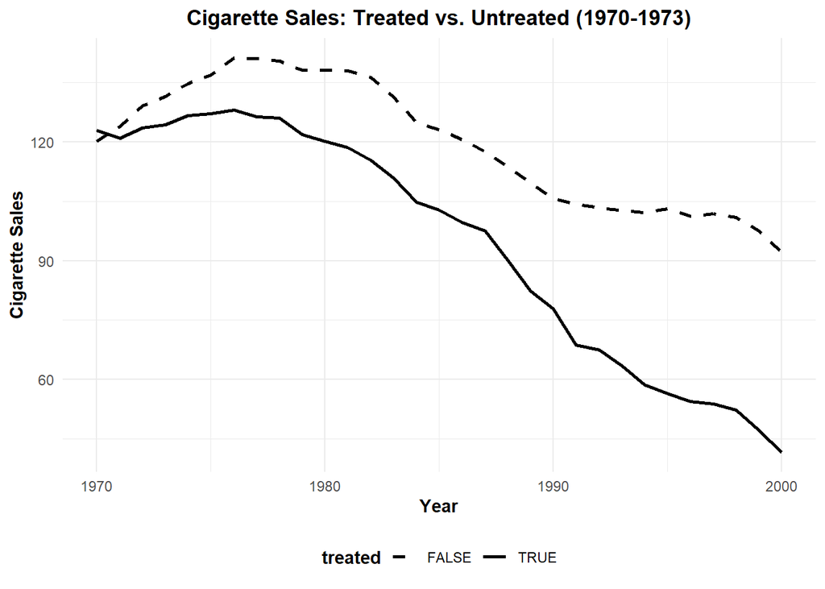

```r
smoking.plot <- smoking %>%
  select(state, year, cigsale) %>%
  mutate(treated = state=="California") %>%
  group_by(treated, year) %>%
  summarize_all(mean, .groups = "drop")

ggplot(smoking.plot, aes(x = year, y = cigsale, color = treated, group = treated)) +
 geom_line(aes(linetype = treated), color = "black", linewidth = 1) +
  scale_linetype_manual(values = c("dashed", "solid")) +
  labs(title = "Cigarette Sales: Treated vs. Untreated (1970-1973)",
       x = "Year",
       y = "Cigarette Sales",
       color = "Treatment Status") +
  theme_minimal() +
  theme(
    legend.position = "bottom",
    plot.title = element_text(face = "bold", hjust = 0.5),
    axis.title = element_text(face = "bold"),
    legend.title = element_text(face = "bold")
  )
```

### Running the Synthetic Control Analysis

1. **`synth` Function:**

The `synth` function from the `Synth` package is used to perform the core Synthetic Control analysis. It takes the output from the `dataprep` function (`dataprep.out` in our case) as input and constructs the synthetic control group. This synthetic control group is a weighted average of the control units that best resembles the treated unit (state 3 in this case) in terms of the pre-treatment characteristics.

```r
   synth.out = synth(data.prep.obj = dataprep.SC)
```

The `synth.out` object stores the results of the analysis, including information about the weights assigned to each control unit in the synthetic control group.

2. **Summary of Optimization:**

The `synth.tab` function displays a summary table of the optimization process. This table provides insights into how well the synthetic control matches the treated group before the treatment and the final weights.

```r
print(synth.tab(dataprep.res = dataprep.SC, synth.res = synth.out))
```

```
$tab.pred
                            Treated Synthetic Sample Mean
special.lnincome.1980.1988   10.077     9.859       9.829
special.retprice.1980.1988   89.422    89.318      87.266
special.age15to24.1980.1988   0.174     0.174       0.173
special.beer.1984.1988       24.280    24.095      23.655
special.cigsale.1975        127.100   126.897     136.932
special.cigsale.1980        120.200   120.248     138.089
special.cigsale.1988         90.100    91.432     113.824

$tab.v
                            v.weights
special.lnincome.1980.1988  0.001
special.retprice.1980.1988  0.031
special.age15to24.1980.1988 0.003
special.beer.1984.1988      0.012
special.cigsale.1975        0.493
special.cigsale.1980        0.392
special.cigsale.1988        0.068

$tab.w
   w.weights     unit.names unit.numbers
1      0.000        Alabama            1
2      0.000       Arkansas            2
4      0.175       Colorado            4
5      0.062    Connecticut            5
6      0.000       Delaware            6
7      0.000        Georgia            7
8      0.001          Idaho            8
9      0.000       Illinois            9
10     0.000        Indiana           10
11     0.000           Iowa           11
12     0.000         Kansas           12
13     0.000       Kentucky           13
14     0.000      Louisiana           14
15     0.000          Maine           15
16     0.000      Minnesota           16
17     0.000    Mississippi           17
18     0.000       Missouri           18
19     0.182        Montana           19
```

[output cut: 9 more lines]

```
29     0.000   Rhode Island           29
30     0.000 South Carolina           30
31     0.000   South Dakota           31
32     0.000      Tennessee           32
33     0.000          Texas           33
34     0.343           Utah           34
35     0.000        Vermont           35
36     0.000       Virginia           36
37     0.000  West Virginia           37
38     0.000      Wisconsin           38
39     0.000        Wyoming           39

$tab.loss
         Loss W   Loss V
[1,] 0.00170442 3.209078
```

3. **Trends over Time:**

The `path.plot` function is used to visualize the trends in the dependent variable (cigarette sales) for both the treated group and the synthetic control group. This plot helps us understand the changes over time and identify any potential effects of the treatment.

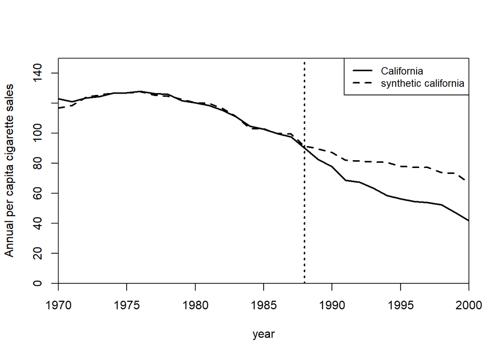

```r
    path.plot(synth.res = synth.out,
            dataprep.res = dataprep.SC,
            tr.intake = 1988,
            Ylab = c("Annual per capita cigarette sales"),
            Xlab = c("year"),
            Ylim = c(0,150),
            Legend = c("California","synthetic california"))
```

4. **Treatment Effect:**

The `gaps.plot` function is employed to plot the difference in the dependent variable between the treated group and the synthetic control group. This plot allows us to isolate the potential effect of the treatment by visually inspecting the gap between the two lines.

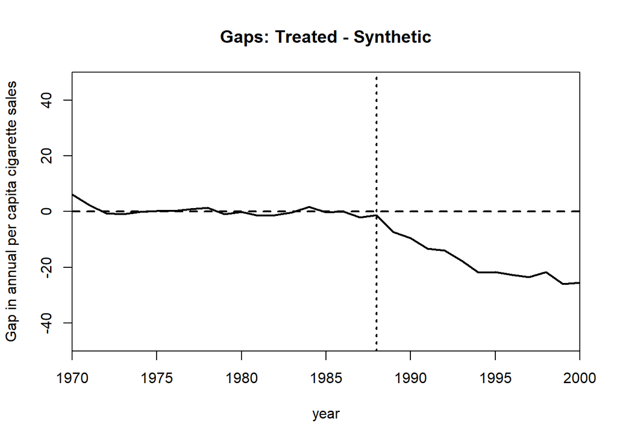

```r
   gaps.plot(synth.res = synth.out,
           dataprep.res = dataprep.SC,
           tr.intake = 1988,
           Ylab = c("Gap in annual per capita cigarette sales"),
           Xlab = c("year"),
           Ylim = c(-50,50))
```

5. **Calculating the Difference:**

The code snippet `diff.sales <- dataprep.SC$Y1plot - (dataprep.SC$Y0plot %*% synth.out$solution.w)` calculates the difference in the dependent variable between the treated group and the synthetic control group for each time period. This can be used for further analysis of the treatment effect. It basically carries the ATET for each post treatment period.

For example, we can calculate an average ATET over all post treatment periods:

```r
diff.sales <- dataprep.SC$Y1plot - (dataprep.SC$Y0plot %*% synth.out$solution.w)
post.dum <- 1970:2000>1988

mean(diff.sales[post.dum])
```

```
[1] -18.71948
```

### Inference

There is currently no built in function available for inference in the `Synth` package that would allow to do the placebo test.

The basic idea is to use the process above but using all the other states as treated unit and then comparing the effect of California with the effect of the other states (that are actually not treated).

The `synthdid` package for synthetic difference-in-difference has a placebo test implemented. It is not available on CRAN but needs to be installed from GitHub.

## Synthetic DID

The following briefly outlines the results of the synthetic DID approach.

```r
# Install the package from github for first time use
# devtools::install_github("synth-inference/synthdid")

library(synthdid)

# Load the california data in approrpiate format for this analyis
data('california_prop99')

# Prepare data further for the analysis
dataprep.SDID <- panel.matrices(california_prop99)

# Run synthetic DID approach
sdid.out <- synthdid_estimate(dataprep.SDID$Y, dataprep.SDID$N0, dataprep.SDID$T0)

# Show main results
summary(sdid.out)
```

```
$estimate
[1] -15.60383

$se
     [,1]
[1,]   NA

$controls
               estimate 1
Nevada              0.124
New Hampshire       0.105
Connecticut         0.078
Delaware            0.070
Colorado            0.058
Illinois            0.053
Nebraska            0.048
Montana             0.045
Utah                0.042
New Mexico          0.041
Minnesota           0.039
Wisconsin           0.037
West Virginia       0.034
North Carolina      0.033
Idaho               0.031
Ohio                0.031
Maine               0.028
Iowa                0.026

$periods
     estimate 1
1988      0.427
1986      0.366
1987      0.206

$dimensions
          N1           N0 N0.effective           T1           T0 T0.effective
       1.000       38.000       16.388       12.000       19.000        2.783
```

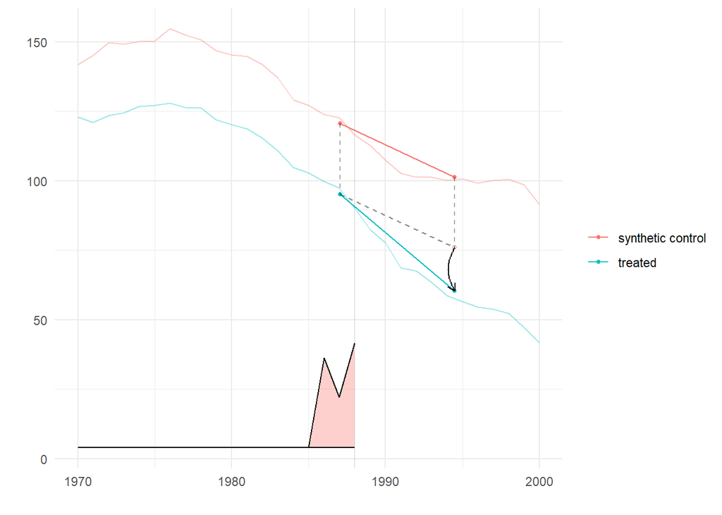

```r
# Plot the results
plot(sdid.out)+theme_minimal()
```

The result is quite similar but we can see that the synthetic control group in this case has a level difference and is not completely matched on the treatment trend.

We can also learn that it mainly uses the last three years before the policy change to match the trends.

We can also visually analyze to which degree units contributed to the synthetic control:

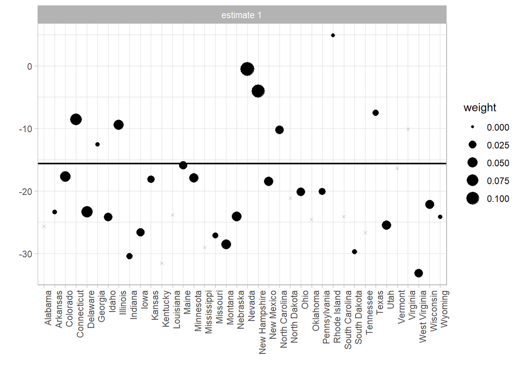

```r
synthdid_units_plot(sdid.out)
```

We can get an estimate of the standard error using placebo tests:

```r
sqrt(vcov(sdid.out, method='placebo'))
```

```
         [,1]
[1,] 9.197265
```

### Comparing the three methods on the smoking data

The `synthdid` package also has functions to implement the DID and the SC method and to compare the three methods.

We will do this in the following:

```r
sc.out   = sc_estimate(dataprep.SDID$Y, dataprep.SDID$N0, dataprep.SDID$T0)
did.out  = did_estimate(dataprep.SDID$Y, dataprep.SDID$N0, dataprep.SDID$T0)
estimates = list(did.out, sc.out, sdid.out)
names(estimates) = c('Diff-in-Diff', 'Synthetic Control', 'Synthetic Diff-in-Diff')
print(unlist(estimates))
```

```
          Diff-in-Diff      Synthetic Control Synthetic Diff-in-Diff
             -27.34911              -19.61966              -15.60383
```

Note: Differences to the previous SC estimate arise because this package does not use the covariates but only pre-treatment outcomes for calculating the weights.

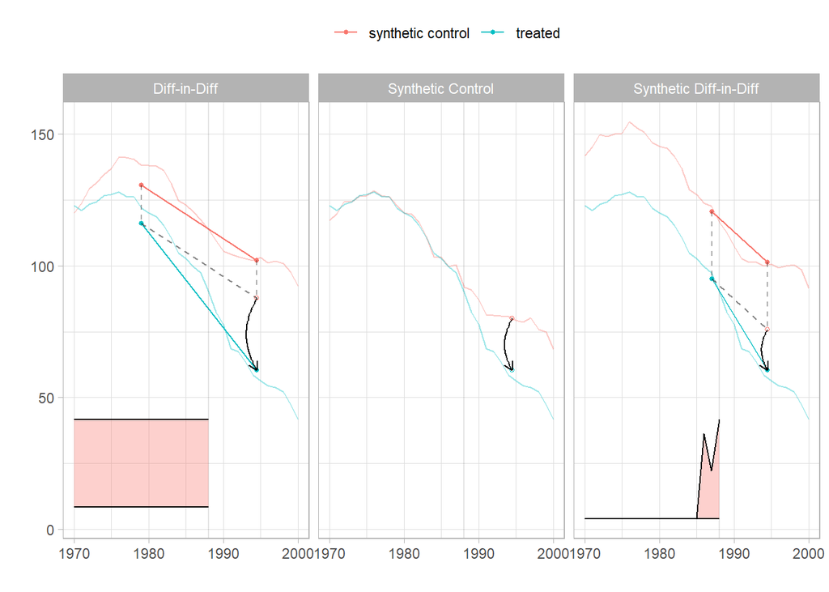

```r
synthdid_plot(estimates, facet.vertical = FALSE)
```

## References

Abadie, A., Diamond, A., & Hainmueller, J. (2010). Synthetic control methods for comparative case studies: Estimating the effect of California’s tobacco control program. Journal of the American Statistical Association, 105(490), 493-505.

Arkhangelsky, D., Athey, S., Hirshberg, D. A., Imbens, G. W., & Wager, S. (2021). Synthetic difference-in-differences. American Economic Review, 111(12), 4088-4118.